# Homework #3

### Directions

For this assignment you should record your answers in an R Markdown file and submit the compiled output as a pdf.

*Homework #3 is due Friday 3/20 by 10:00pm*

### Question #1

The data frame `diamonds` is contained within the `ggplot2` package. These data record the attributes of several thousand diamonds sold by a wholesale online retailer. For this question, your goal is to recreate the graph shown below as closely as possible. A few hints:

- Pay attention to the scales, theme, and labels
- The argument `alpha = 0.3` is used to give each point 30% opacity.
- The default colors are used

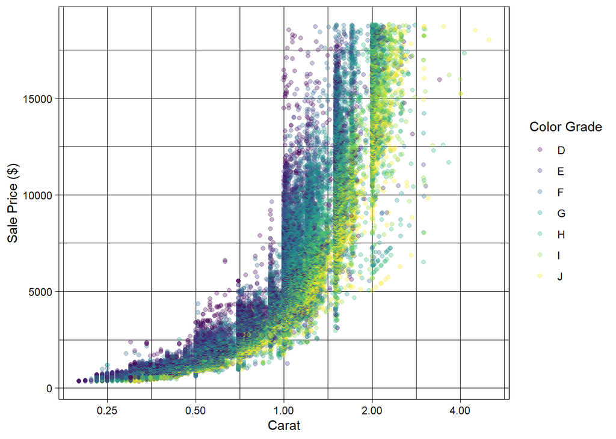

```r
library(ggplot2)  # Make sure you have this package installed
data("diamonds") # loads the built-in "diamonds" data set
```

$~$

### Question #2 - Part A

The “babynames” package contains a data set documenting the number and frequency of all names that appear at least 5 times within a given year as recorded by the United States Social Security Administration.

The code below will load this dataset. You will likely need to install the package unless you’ve previously used it.

```r
#install.packages("babynames")
library(babynames)
data("babynames")
```

Create a subset of `babynames` named `my_subset` that contains information on the names: `"Ryan", "Jeff", "Shonda", "Jonathan", "Collin", "Nathan", "Vinny"`

```r
# fixed w/ smooth
ggplot(my_subset, aes(x = year, y = n, color = name)) + geom_smooth(se=F)
```

[output not shown]

$~$

### Question #2 - Part B

Create a new graph that fixes the problem you identified in Part A and appropriately displays the frequency of each name over time.

$~$

### Question #3

Consider the following `ggplot` code:

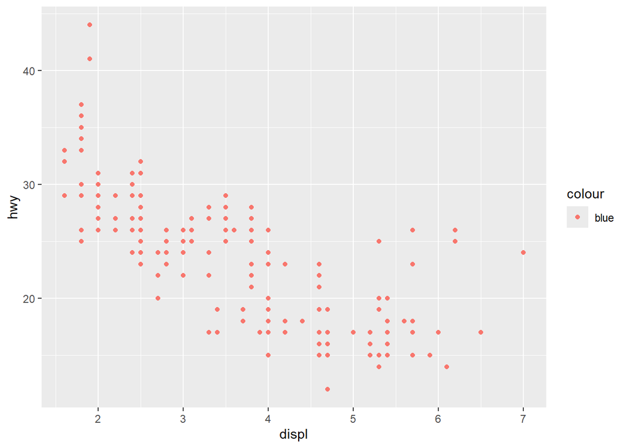

```r
ggplot(data = mpg) +
  geom_point(mapping = aes(x = displ, y = hwy, color = "blue"))
```

**Part A**: Why are the data-points in the scatter plot not colored blue? Briefly explain.

**Part B**: Modify the code so that the points are properly shown as blue.

```r
## Put your code for 2-B here
```

$~$